# Geospatial Analysis with R

Class 11

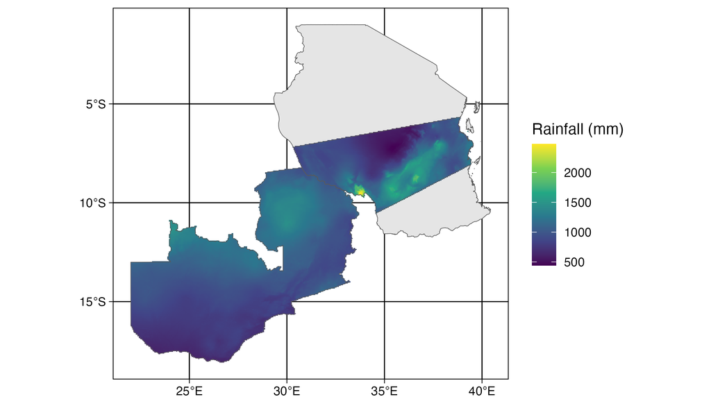

```r
library(dplyr)
library(ggplot2)
library(sf)
tz <- st_read(here::here("external/data/tanzania.geojson"))
sagcot <- st_read(here::here("external/data/sagcotcl.geojson"))
zambia <- st_read(
  system.file("extdata/districts.geojson", package = "geospaar")
) %>% st_union()
prec <- geodata::worldclim_global(var = "prec", res = 2.5,
                                  path = "external/data/")
precsum <- terra::app(prec, sum)
tz_sagcot <- terra::vect(st_union(sagcot, zambia))
prec_tzzam <- terra::mask(terra::crop(precsum, tz_sagcot), tz_sagcot)

prec_stars <- stars::st_as_stars(prec_tzzam)
p <- ggplot() +
  geom_sf(data = tz) +
  stars::geom_stars(data = prec_stars) +
  scale_fill_viridis_c(name = "Rainfall (mm)", na.value = "transparent") +
  geom_sf(data = zambia, fill = "transparent") +
  geom_sf(data = sagcot, fill = "transparent") +
  labs(x = NULL, y = NULL) +
  theme_linedraw()
ggsave(p, filename = "docs/figures/tanzam_rainfall.png", height = 4,
       width = 7, units = "in", dpi = 300)
```

## Exercises

- Use `lapply` to make three `data.frame`s captured in a list `l`, each composed of one randomly sampled column `v1` (selecting from integers 1:10, with length = 20), and the second being `v2` composed of lowercase letters, randomly selected using `sample`, also of length 20.
- The iterator in the `lapply` should be 10, 20, 30, which become the random seeds for the sampling (in the body of the `lapply`)
- After making `l`, use a `for` loop to iterate through each element of `l`, writing each out to a folder `external/data/` in your project.
- Change the name of each as part of the iteration, so that `l[[1]]` is written out as `external/data/dataset1.csv`, etc. Hint: you can use `paste0` to make each file path and name.
- After writing these out, use another `lapply` to read back in the three datasets into a new list `l2`. Bonus: Use `dir` to programmatically read in the file paths from your `external/data` folder.

## Working with data, continued

### `do.call` / `bind_rows`

```r
sz <- 100
for(i in 1:3) {
  set.seed(i)
  d <- data.frame(
    id = 1:sz,
    v1 = runif(sz, min = 2, max = 12),
    grp = paste0("g", i)
  ) %>% mutate(v2 = v1 + rnorm(sz, mean = 2, sd = 2)) %>%
    select(id, v1, v2, grp)
  readr::write_csv(d, file = file.path(tempdir(), paste0("dataset", i, ".csv")))
}
# ggplot(d) + geom_point(aes(x = v1, y = v2))

fs <- list.files(tempdir(), pattern = "dataset.*.csv", full.names = TRUE)
# dat <- do.call(rbind, lapply(fs, readr::read_csv))
dat <- bind_rows(lapply(fs, readr::read_csv))

plot(dat$v1, dat$v2)
```

## Manipulating and analyzing data

- reshape
- mutate
- select
- joins
- split-apply-combine
- plotting
- regression

## Reshape

```r
dat %>%
  pivot_wider(names_from = grp, values_from = v1:v2)

dat %>%
  select(-v1) %>%
  pivot_wider(names_from = grp, values_from = v2)

dat_wide <- dat %>%
  select(id, v2, grp) %>%
  pivot_wider(names_from = grp, values_from = v2)

dat_long <- dat_wide %>%
  pivot_longer(g1:g3, names_to = "grp", values_to = "v2") %>%
  arrange(grp)

dat_long2 <- dat_wide %>%
  pivot_longer(g1:g3, names_to = "grp", values_to = "v2")

cbind(dat, dat_long) %>% head()
bind_cols(dat, dat_long)
```

## Joins

```r
cbind(dat, dat_long2) %>% head()
# bind_cols(dat, dat_long)

dat %>% left_join(dat_long2)
dat_long2 %>%
  rename(grp2 = grp) %>%
  select(id, grp2, v2) %>%
  left_join(dat, ., by = c("id", "v2", "grp" = "grp2"))

dat_long2 %>%
  rename(grp2 = grp) %>%
  select(id, grp2, v2) %>%
  left_join(dat %>% select(-v2), ., by = c("id", "grp" = "grp2")) %>%
  select(id:v1, v2, grp)
```

- Note: understand the differences between `full_join`, `inner_join`, `right_join`, and `left_join`.

## Split-apply-combine

```r
set.seed(10)
dat <- data.frame(v1 = 1:100, v2 = sample(0:10, size = 100, replace = TRUE),
                  grp = sample(letters[1:3], size = 100, replace = TRUE))

sapply(sort(unique(dat$grp)), function(x) {
  colMeans(dat[dat$grp == x, c("v1", "v2")])
})

dat %>%
  group_by(grp) %>%
  summarise(across(c(v1, v2), mean))
```